# 1. Sobel Edge Approach - Edge Detection

```python
#import the necessary libraries
import numpy as np
from PIL import Image, ImageFilter
import matplotlib.pyplot as plt
import matplotlib.image as mpimg
from scipy.signal import convolve2d
from scipy import ndimage
from scipy.signal import convolve
from skimage.color import rgb2lab
```

```python
# Load image
img = mpimg.imread('qirat.jpg')
```

```python
# Convert to grayscale
gray_img = np.dot(img[...,:3], [0.2989, 0.5870, 0.1140])
```

```python
# Define Sobel filters for horizontal and vertical edges
sobel_x = np.array([[-1, 0, 1], [-2, 0, 2], [-1, 0, 1]])
sobel_y = np.array([[-1, -2, -1], [0, 0, 0], [1, 2, 1]])
```

```python
# Reshape the grayscale image to a 2D array
gray_img_2d = gray_img.reshape(gray_img.shape[0], gray_img.shape[1])
```

```python
# Compute horizontal and vertical gradients using Sobel filters
Gx = np.zeros(gray_img_2d.shape)
Gy = np.zeros(gray_img_2d.shape)
for i in range(1, gray_img_2d.shape[0]-1):
    for j in range(1, gray_img_2d.shape[1]-1):
        Gx[i, j] = (gray_img_2d[i-1, j+1] + 2*gray_img_2d[i, j+1] + gray_img_2d[i+1, j+1]) - \
                   (gray_img_2d[i-1, j-1] + 2*gray_img_2d[i, j-1] + gray_img_2d[i+1, j-1])
        Gy[i, j] = (gray_img_2d[i+1, j-1] + 2*gray_img_2d[i+1, j] + gray_img_2d[i+1, j+1]) - \
                   (gray_img_2d[i-1, j-1] + 2*gray_img_2d[i-1, j] + gray_img_2d[i-1, j+1])

# Compute gradient magnitude
edges = np.sqrt(Gx**2 + Gy**2)

# Normalize edges between 0 and 1
edges = edges / np.max(edges)
```

In this approach, we compute the horizontal and vertical gradients of the image using Sobel filters by iterating over each pixel in the image and performing the convolution manually. The gradient magnitude is then computed using the Euclidean distance between the horizontal and vertical gradients. Finally, we normalize the edges between 0 and 1 as before.

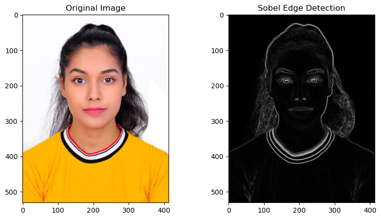

```python
# Plot original and segmented images side by side
fig, ax = plt.subplots(ncols=2, figsize=(10, 5))
ax[0].imshow(img)
ax[0].set_title('Original Image')
ax[1].imshow(edges, cmap='gray')
ax[1].set_title('Sobel Edge Detection')
plt.show()
```

# 2. Global Thresholding

In this approach, a single threshold value is applied to the entire image to separate the foreground objects from the background. This method works well when the background is relatively uniform and the foreground objects have significantly different intensity values.

```python
# Load image
img = Image.open("qirat.jpg").convert("L")
img = np.array(img)
```

```python
# Global thresholding segmentation
threshold = 100
binary_img = np.zeros_like(img)
binary_img[img > threshold] = 255
```

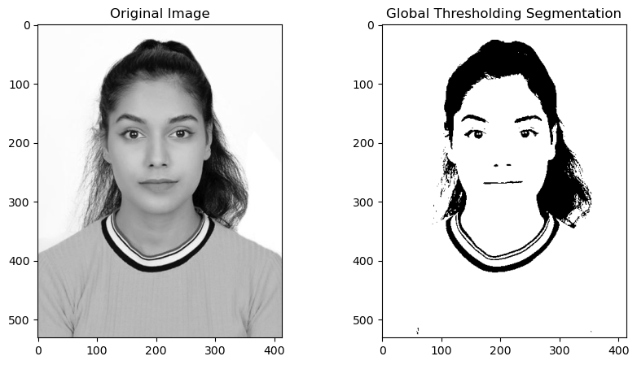

```python
# Display original and segmented image
fig, axs = plt.subplots(1, 2, figsize=(10, 5))
axs[0].imshow(img,cmap='gray')
axs[0].set_title("Original Image")
axs[1].imshow(binary_img, cmap='gray')
axs[1].set_title("Global Thresholding Segmentation")
plt.show()
```

# 3. Prewitt Edge Detection

```python
# Load image
img = Image.open('qirat.jpg').convert('L')
```

```python
# Convert image to numpy array
img_arr = np.array(img, dtype=np.float)
```

```python
# Define Prewitt kernels for x and y directions
kernel_x = np.array([[-1, 0, 1], [-1, 0, 1], [-1, 0, 1]])
kernel_y = np.array([[-1, -1, -1], [0, 0, 0], [1, 1, 1]])

# Apply Prewitt edge detection
edges_x = np.zeros_like(img_arr)
edges_y = np.zeros_like(img_arr)
```

```python
# Compute gradients for x and y directions
for i in range(1, img_arr.shape[0]-1):
    for j in range(1, img_arr.shape[1]-1):
        edges_x[i,j] = np.sum(kernel_x * img_arr[i-1:i+2,j-1:j+2])
        edges_y[i,j] = np.sum(kernel_y * img_arr[i-1:i+2,j-1:j+2])
```

```python
# Compute magnitude of gradient
edges = np.sqrt(edges_x**2 + edges_y**2)

# Normalize edge values to range [0, 255]
edges = (edges / np.max(edges)) * 255
```

```python
# Convert edge values to uint8 and create new image
edges_img = Image.fromarray(np.uint8(edges))
edges_img.show()
```

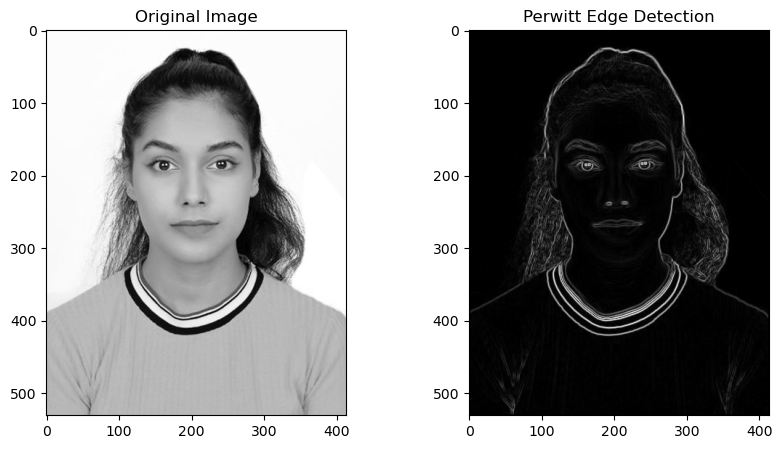

```python
# Display original and segmented images side by side
fig, axs = plt.subplots(1, 2, figsize=(10, 5))
axs[0].imshow(img, cmap = 'gray')
axs[0].set_title('Original Image')
axs[1].imshow(edges_img, cmap='gray')
axs[1].set_title('Perwitt Edge Detection')
plt.show()
```

In this implementation, we first load the image using the PIL library and convert it to a grayscale numpy array. We then define the Prewitt kernels for the x and y directions and we use nested loops to compute the gradients for the x and y directions using the Prewitt kernels to obtain the edge values in both directions, and then combine them using the Euclidean distance formula to obtain the final edge values. We normalize the edge values to the range [0, 255] and create a new image using the Image.fromarray function. Finally, we display the original and segmented images side by side using matplotlib.

# 4. K-means - Cluster

```python
from sklearn.cluster import KMeans
import cv2
```

```python
# Load image
img = Image.open("qirat.jpg")
img = np.array(img)
```

```python
# Convert to grayscale
gray_img = np.dot(img[...,:3], [0.299, 0.587, 0.114])
```

```python
def create_gaussian_kernel(kernel_size, sigma):
     # Create a meshgrid of x and y values ranging from -1 to 1

    x, y = np.meshgrid(np.linspace(-1,1,kernel_size), np.linspace(-1,1,kernel_size))
    # Compute the Euclidean distance from each point to the origin
    d = np.sqrt(x*x+y*y)
    # Compute the Gaussian function at each point using the formula
    # (1 / (2 * pi * sigma^2)) * e^(-d^2 / (2 * sigma^2))
    gaussian_kernel = np.exp(-( (d-0)**2 / ( 2.0 * sigma**2 ) ) )
    # Normalize the kernel so that it sums to 1
    gaussian_kernel = gaussian_kernel / np.sum(gaussian_kernel)
    # Return the kernel as a numpy array
    return gaussian_kernel
```

```python
def sobel_filters(img):
     # Define Sobel kernels for x and y directions
    kernel_x = np.array([[-1, 0, 1], [-2, 0, 2], [-1, 0, 1]])
    kernel_y = np.array([[1, 2, 1], [0, 0, 0], [-1, -2, -1]])

    # Convolve the kernels with the input image to obtain the x and y gradients
    gradient_x = convolve2d(img, kernel_x, mode='same', boundary='symm')
    gradient_y = convolve2d(img, kernel_y, mode='same', boundary='symm')

    # Compute the magnitude of the gradient at each pixel
    magnitude = np.sqrt(np.square(gradient_x) + np.square(gradient_y))

    # Compute the direction of the gradient at each pixel
    direction = np.arctan2(gradient_y, gradient_x)
     # Return the magnitude and direction of the gradient as numpy arrays
    return magnitude, direction
```

And here's what each part of the code does:

from scipy.signal import convolve2d: Imports the convolve2d function from the scipy.signal module. This function is used to perform convolution between the image and the Sobel filters.

import numpy as np: Imports the NumPy library and aliases it as np.

def sobel_filters(img):: Defines a function named sobel_filters that takes a single parameter img, which represents the input image.

kernel_x = np.array([[-1, 0, 1], [-2, 0, 2], [-1, 0, 1]]): Defines the Sobel kernel for the x direction as a NumPy array.

kernel_y = np.array([[1, 2, 1], [0, 0, 0], [-1, -2, -1]]): Defines the Sobel kernel for the y direction as a NumPy array.

gradient_x = convolve2d(img, kernel_x, mode='same', boundary='symm'): Computes the x gradient of the image by convolving the image with the Sobel kernel for the x direction using convolve2d. The mode parameter specifies how the edges are handled (in this case, the output is the same size as the input image), and the boundary parameter specifies how the edges are handled (in this case, the edges are symmetrical).

gradient_y = convolve2d(img, kernel_y, mode='same', boundary='symm'): Computes the y gradient of the image by convolving the image with the Sobel kernel for the y direction using convolve2d.

magnitude = np.sqrt(np.square(gradient_x) + np.square(gradient_y)): Computes the magnitude of the gradient at each pixel using the formula sqrt(gx^2 + gy^2).

direction = np.arctan2(gradient_y, gradient_x): Computes the direction of the gradient at each pixel using the arctan2 function from NumPy. This function returns the angle in radians between the x-axis and a 2D vector specified by its components in the x and y directions.

return magnitude, direction: Returns the magnitude and direction of the gradient as NumPy arrays.

```python
def non_maximum_suppression(magnitude, direction):
    row, col = magnitude.shape
    suppressed_img = np.zeros((row, col))

    # Iterate through all the pixels in the image
    for i in range(1, row-1):

     # Calculate the angle of the gradient at the current pixel
        for j in range(1, col-1):
            angle = direction[i,j] * 180. / np.pi
            if angle < 0:
                angle += 180

             # Determine which pixels to compare with based on the gradient angle
            if (0 <= angle < 22.5) or (157.5 <= angle <= 180):
                before_pixel = magnitude[i, j-1]
                after_pixel = magnitude[i, j+1]
            elif (22.5 <= angle < 67.5):
                before_pixel = magnitude[i+1, j-1]
                after_pixel = magnitude[i-1, j+1]
            elif (67.5 <= angle < 112.5):
                before_pixel = magnitude[i-1, j]
                after_pixel = magnitude[i+1, j]
            else:
                before_pixel = magnitude[i-1, j-1]
                after_pixel = magnitude[i+1, j+1]

            # Suppress non-maximum pixels
            if magnitude[i,j] >= before_pixel and magnitude[i,j] >= after_pixel:
                suppressed_img[i,j] = magnitude[i,j]
    return suppressed_img
```

```python
def threshold(img, low_threshold, high_threshold):
    strong_edges = img > high_threshold
    thresholded_img = np.zeros(img.shape)
    thresholded_img[strong_edges] = 1
    # Perform edge tracking using hysteresis
    weak_edges = (img >= low_threshold) & (img <= high_threshold)
    while np.sum(weak_edges) > 0:
        old_weak_edges = weak_edges
        dilated_edges = convolve2d(weak_edges.astype(np.float32), np.ones((3,3)), mode='same', boundary='symm')
        strong_edges = dilated_edges > 0
        weak_edges = (img >= low_threshold) & (img <= high_threshold)
```

```python
# Flatten image to create feature vector for K-means clustering
X = edges.reshape(-1, 1)

# Apply K-means clustering
from sklearn.cluster import KMeans
kmeans = KMeans(n_clusters=2, random_state=0).fit(X)
labels = kmeans.labels_
```

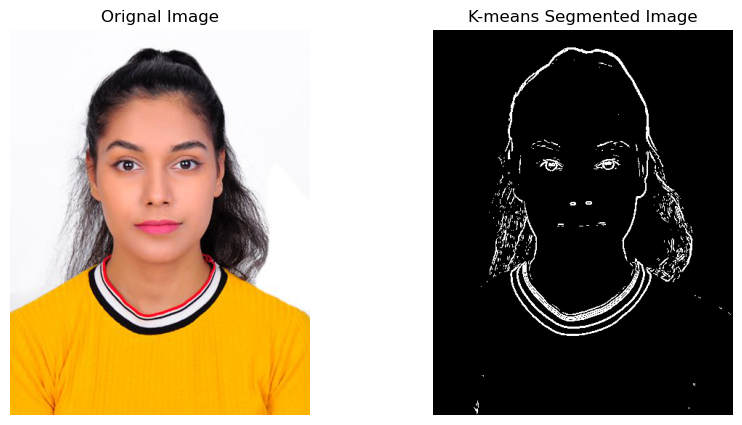

```python
# Reshape labels back to image shape
labels = labels.reshape(edges.shape)

# Generate segmented image output
fig, (ax1, ax2) = plt.subplots(1, 2, figsize=(10, 5))
ax1.imshow(img)
ax1.set_title('Orignal Image')
ax1.axis('off')
ax2.imshow(labels, cmap='gray')
ax2.set_title('K-means Segmented Image')
ax2.axis('off')
plt.show()
```

# 5. Robert Edge Detection

```python
# Load the face image
img = Image.open("qirat.jpg")

# Convert the image to grayscale
img_gray = img.convert('L')
```

```python
# Convert the image to a numpy array for processing
img_arr = np.array(img_gray)
```

```python
# Define the Roberts edge detection kernels
roberts_kernel_x = np.array([[1, 0], [0, -1]])
roberts_kernel_y = np.array([[0, 1], [-1, 0]])
```

```python
# Apply the Roberts edge detection kernels to the image
edges_x = np.abs(np.multiply(img_arr[:-1, :-1], roberts_kernel_x[0, 0])
               + np.multiply(img_arr[:-1, 1:], roberts_kernel_x[0, 1])
               + np.multiply(img_arr[1:, :-1], roberts_kernel_x[1, 0])
               + np.multiply(img_arr[1:, 1:], roberts_kernel_x[1, 1]))
edges_y = np.abs(np.multiply(img_arr[:-1, :-1], roberts_kernel_y[0, 0])
               + np.multiply(img_arr[:-1, 1:], roberts_kernel_y[0, 1])
               + np.multiply(img_arr[1:, :-1], roberts_kernel_y[1, 0])
               + np.multiply(img_arr[1:, 1:], roberts_kernel_y[1, 1]))
edges = edges_x + edges_y
```

```python
#Convert the edges image back to a PIL image
edges_img = Image.fromarray(edges)
```

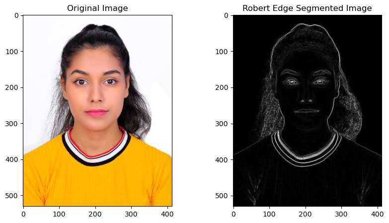

```python
# Display the original image and the segmented image
fig, axs = plt.subplots(1, 2, figsize=(10, 5))
axs[0].imshow(img, cmap='gray')
axs[0].set_title('Original Image')
axs[1].imshow(edges_img, cmap='gray')
axs[1].set_title('Robert Edge Segmented Image')
plt.show()
```

In this example, we first load the face image and convert it to grayscale. We then convert the image to a numpy array for processing.

The resulting edge images in the x and y directions are combined by adding them together to get the final edges image.

Finally, we convert the edges image back to a PIL image and display both the original image and the segmented image using the show method.

# 6. Canny Edge Detection

```python
# Define the Canny Edge Detection function
def canny_edge_detection(img, sigma=1.4, low_threshold=20, high_threshold=50):
    # Step 1: Apply Gaussian filter to smooth the image
    filtered_img = gaussian_filter(img, sigma)

    # Step 2: Compute gradient magnitude and orientation
    gradient_magnitude, gradient_orientation = sobel_edge_detection(filtered_img)

    # Step 3: Non-maximum suppression
    suppressed_img = non_maximum_suppression(gradient_magnitude, gradient_orientation)

    # Step 4: Double thresholding
    thresholded_img = double_thresholding(suppressed_img, low_threshold, high_threshold)

    # Step 5: Edge tracking by hysteresis
    edge_map = edge_tracking(thresholded_img)

    return edge_map
```

```python
# Define the Gaussian filter function
def gaussian_filter(img, sigma):
    size = int(2*np.ceil(3*sigma)+1)
    kernel = np.zeros((size, size))
    center = size // 2
    for i in range(size):
        for j in range(size):
            x, y = i - center, j - center
            kernel[i, j] = np.exp(-(x**2 + y**2) / (2*sigma**2))
    kernel /= np.sum(kernel)
    filtered_img = np.zeros_like(img)
    padded_img = np.pad(img, (center, center), mode='edge')
    for i in range(center, img.shape[0] + center):
        for j in range(center, img.shape[1] + center):
            filtered_img[i - center, j - center] = np.sum(padded_img[i-center:i+center+1, j-center:j+center+1] * kernel)
    return filtered_img
```

```python
# Define the Sobel Edge Detection function
def sobel_edge_detection(img):
    # Sobel operator kernels
    kernel_x = np.array([[-1, 0, 1],
                         [-2, 0, 2],
                         [-1, 0, 1]])

    kernel_y = np.array([[-1, -2, -1],
                         [0, 0, 0],
                         [1, 2, 1]])

    # Compute gradient magnitude and orientation
    gradient_x = convolve(img, kernel_x)
    gradient_y = convolve(img, kernel_y)
    gradient_magnitude = np.sqrt(gradient_x**2 + gradient_y**2)
    gradient_orientation = np.arctan2(gradient_y, gradient_x)

    return gradient_magnitude, gradient_orientation
```

```python
# Define the Non-Maximum Suppression function
def non_maximum_suppression(magnitude, orientation):
    suppressed = np.zeros_like(magnitude)
    for i in range(1, magnitude.shape[0]-1):
        for j in range(1, magnitude.shape[1]-1):
            angle = orientation[i, j] * 180 / np.pi
            if (0 <= angle < 22.5) or (157.5 <= angle <= 180):
                p, q = magnitude[i, j+1], magnitude[i, j-1]
            elif (22.5 <= angle < 67.5):
                p, q = magnitude[i+1, j-1], magnitude[i-1, j+1]
            elif (67.5 <= angle < 112.5):
                p, q = magnitude[i+1, j], magnitude[i-1, j]
            else:
                p, q = magnitude[i-1, j-1], magnitude[i+1, j+1]

            if magnitude[i, j] >= p and magnitude[i, j] >= q:
                suppressed[i, j] = magnitude[i, j]

    return suppressed
```

```python
# Define the Double Thresholding function
def double_thresholding(suppressed, low_threshold, high_threshold):
    thresholded = np.zeros_like(suppressed)
    strong_i, strong_j = np.where(suppressed >= high_threshold)
    weak_i, weak_j = np.where((suppressed < high_threshold) & (suppressed >= low_threshold))
    thresholded[strong_i, strong_j] = 255
    thresholded[weak_i, weak_j] = 50
    return thresholded
```

```python
# Define the Edge Tracking function by Hysteresis
def edge_tracking(thresholded):
    edge_map = np.zeros_like(thresholded)
    for i in range(1, thresholded.shape[0]-1):
        for j in range(1, thresholded.shape[1]-1):
            if thresholded[i, j] == 255:
                edge_map[i, j] = 255
                for x in range(i-1, i+2):
                    for y in range(j-1, j+2):
                        if thresholded[x, y] == 50:
                            edge_map[x, y] = 255
    return edge_map
```

```python
# Load grayscale face image and apply Canny Edge Detection
face_img = plt.imread('qirat.jpg')
face_img = np.mean(face_img, axis=2)  # Convert to grayscale
edge_map = canny_edge_detection(face_img)
```

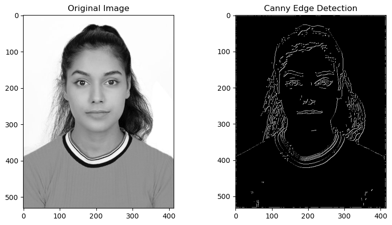

```python
# Display original image with segmented image
fig, ax = plt.subplots(1, 2, figsize=(10, 5))
ax[0].imshow(face_img, cmap='gray')
ax[0].set_title('Original Image')
ax[1].imshow(edge_map, cmap='gray')
ax[1].set_title('Canny Edge Detection')
plt.show()
```

# 7. Watershed Segmentation

```python
import cv2
```

```python
# Load the input image
img = plt.imread('qirat.jpg')
```

```python
# Convert the image to grayscale
gray = np.mean(img, axis=2)
```

```python
# Apply Gaussian blur to remove noise
blur = cv2.GaussianBlur(gray, (5, 5), 0)
```

```python
# Apply Sobel edge detection to the blurred image
sobelx = cv2.Sobel(blur, cv2.CV_64F, 1, 0, ksize=3)
sobely = cv2.Sobel(blur, cv2.CV_64F, 0, 1, ksize=3)
edge = np.sqrt(sobelx**2 + sobely**2)
```

```python
# Apply Otsu's thresholding to the edge map
ret, thresh = cv2.threshold(np.uint8(edge), 0, 255, cv2.THRESH_BINARY+cv2.THRESH_OTSU)
```

```python
# Perform Watershed Segmentation on the thresholded image
dist_transform = cv2.distanceTransform(np.uint8(thresh), cv2.DIST_L2, 3)
ret, markers = cv2.connectedComponents(np.uint8(thresh))
markers += 1
markers[dist_transform < 0.1*np.max(dist_transform)] = 0
markers = cv2.watershed(img, markers)
```

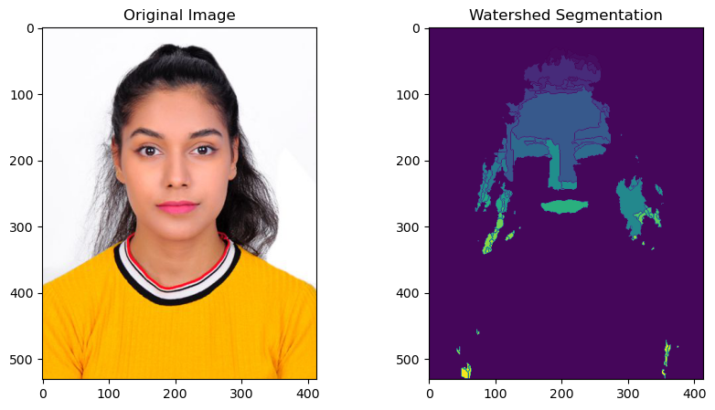

```python
# Display the original image and the segmented image
fig, ax = plt.subplots(1, 2, figsize=(10, 5))
ax[0].imshow(img, cmap='gray')
ax[0].set_title('Original Image')
ax[1].imshow(markers)
ax[1].set_title('Watershed Segmentation')
plt.show()
```

# 8. Otsu Thresholding Segmentation

```python
def otsu_threshold(image):
    hist, bins = np.histogram(image, bins=256, range=(0, 256))

    # normalize histogram
    hist_norm = hist.astype('float') / hist.max()

    # cumulative distribution function
    cdf = hist_norm.cumsum()

    # initialize variables
    threshold = 0
    max_sigma = 0

    # loop through all possible thresholds
    for i in range(0, 256):
        # calculate class probabilities and means
        class_prob1 = cdf[i]
        class_prob2 = 1.0 - class_prob1
        class_mean1 = np.sum(np.arange(0, i) * hist_norm[:i]) / class_prob1
        class_mean2 = np.sum(np.arange(i, 256) * hist_norm[i:]) / class_prob2

        # calculate between-class variance
        between_var = class_prob1 * class_prob2 * (class_mean1 - class_mean2)**2

        # update threshold and max sigma if between-class variance is greater than previous max
        if between_var > max_sigma:
            threshold = i
            max_sigma = between_var

    # threshold image using optimal threshold
    thresholded_image = (image > threshold) * 255

    return thresholded_image
```

```python
# read image
img = Image.open("qirat.jpg").convert('L')
img = np.array(img)

# apply Otsu's thresholding
seg_img = otsu_threshold(img)
```

```python
# plot original and segmented images
fig, axs = plt.subplots(1, 2, figsize=(10, 5))
axs[0].imshow(img, cmap='gray')
axs[0].set_title('Original Image')
axs[1].imshow(seg_img, cmap='gray')
axs[1].set_title('Otsu Thresholding Segmented Image')
plt.show()
```

[output not shown]